# Wine Exploration by Mack Damavandi

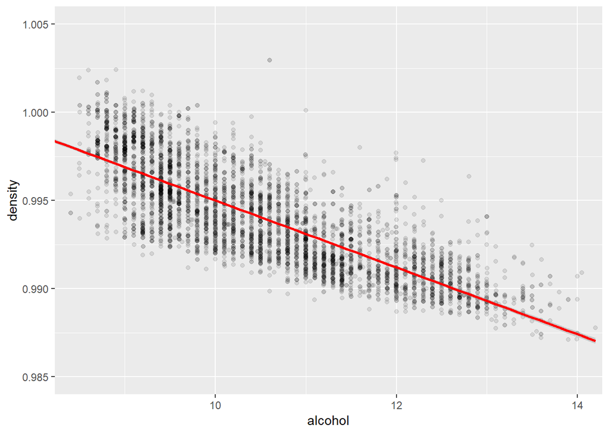

One of the most interesting relationships is that of alcohol to quality. In my mind, this could highlight the subjectivity of the quality scores that were given to the wine.

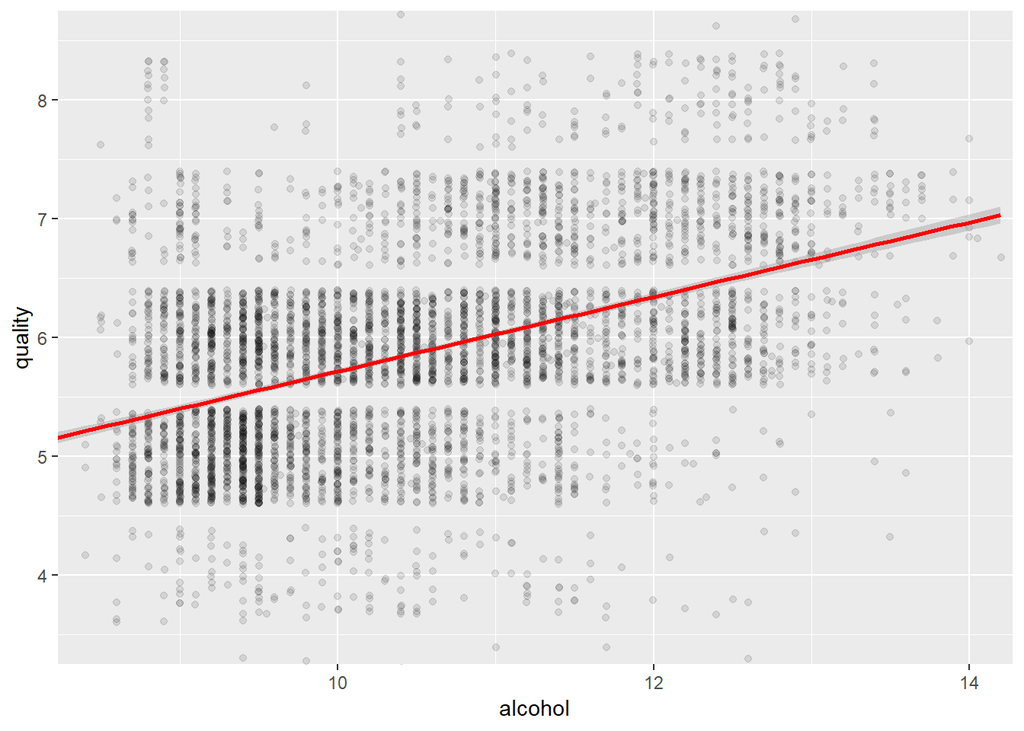

There isn’t any correlation between citric acid and the quality of the wine.

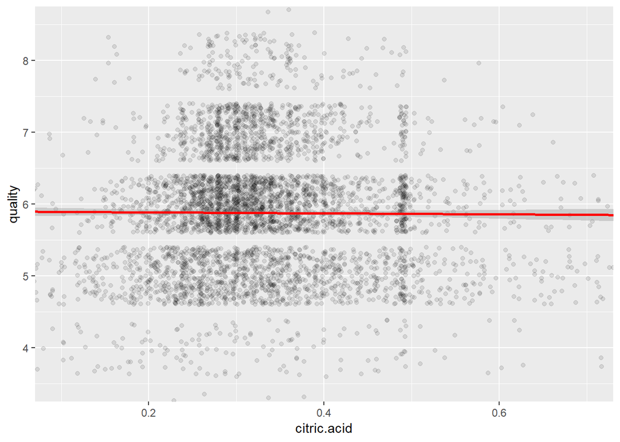

The correlation between the quality of the wine and the residual sugar is slightly negative. This is also counter-intuitive to me. As someone who doesn’t drink wine, I would think that a little more sugar would make it more pleasant, but that seems not to be the case.

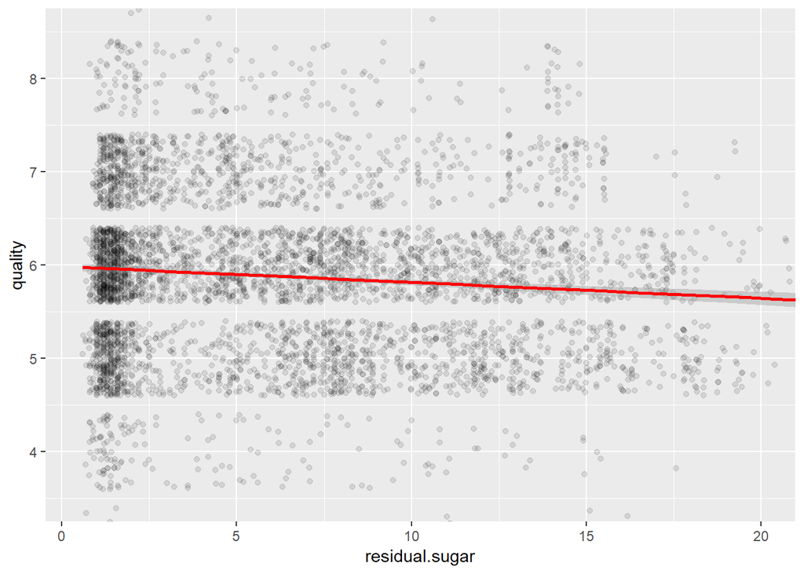

# Bivariate Analysis

For the most part, my features of interest really only had strong relationships with themselves. Citric acid was the only one that didn’t really relate with anything besides the acidity values and pH. Both residual sugar and alcohol had a strong relationship with the density of the wine though, but I don’t think density would really affect the quality of the wine, especially since it is still so close to the density of water.

I would have thought that the relationship between citric acid and volatile acidity would be positive, but it was negative. I would have to do some more research to understand why that is.

### What was the strongest relationship you found?

The strongest relationship that I found was between residual sugar and density, with a correlation coefficient of 0.84. The next strongest was between density and alcohol, with a correlation coefficient of -0.78.

# Multivariate Plots Section

The new variable, quality.factor, factor in R based on the quality. Theredoesn’t appear to be any significant grouping other than the higher quality wines typically having a higher alcohol content.

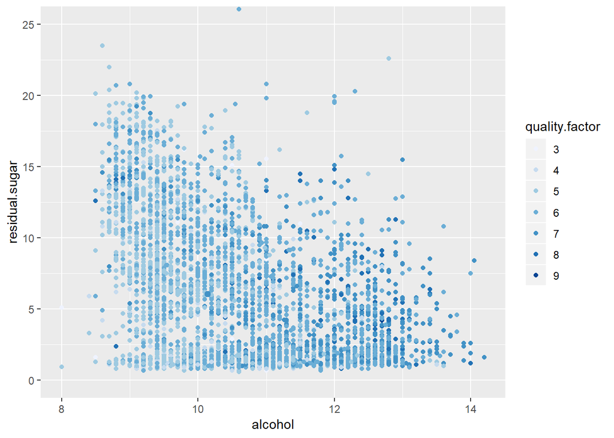

These plots use the other factor, dryness. It doesn’t really appear to be the case that the dryness affects the quality of the rating at all.

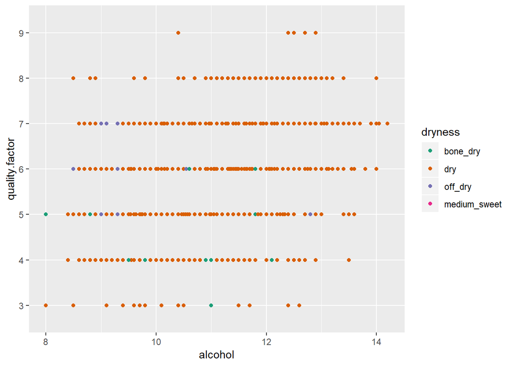

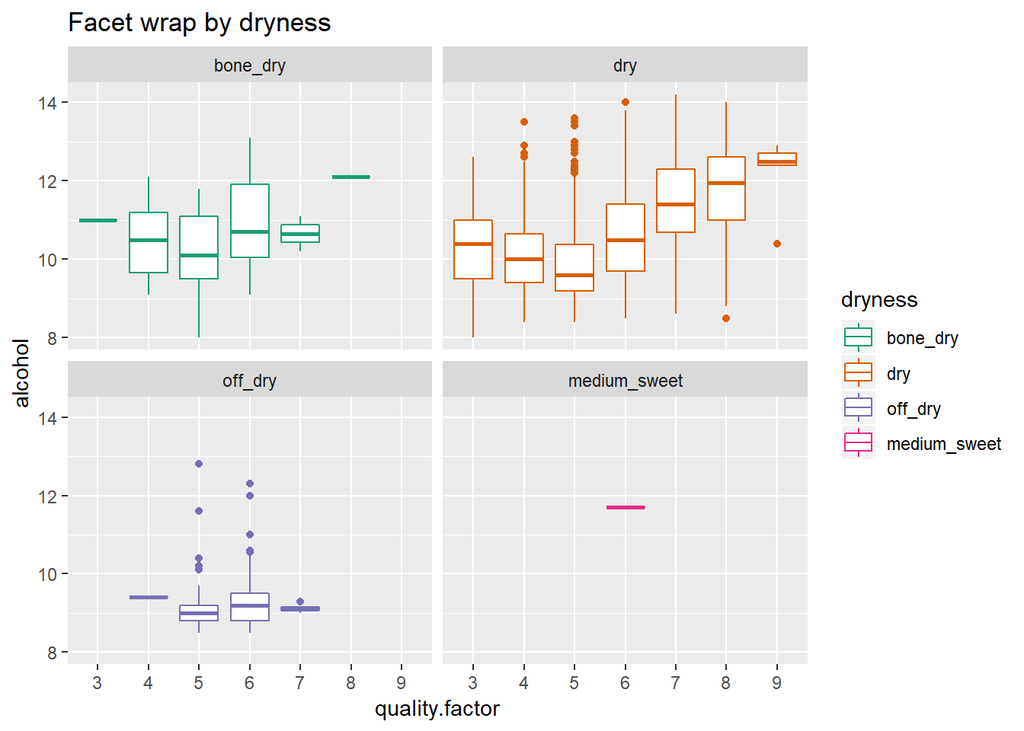

Plotting alcohol/density vs. residual sugar gives us a plot very similar to alcohol vs residual sugar. This makes sense since the density values are very close to 1.

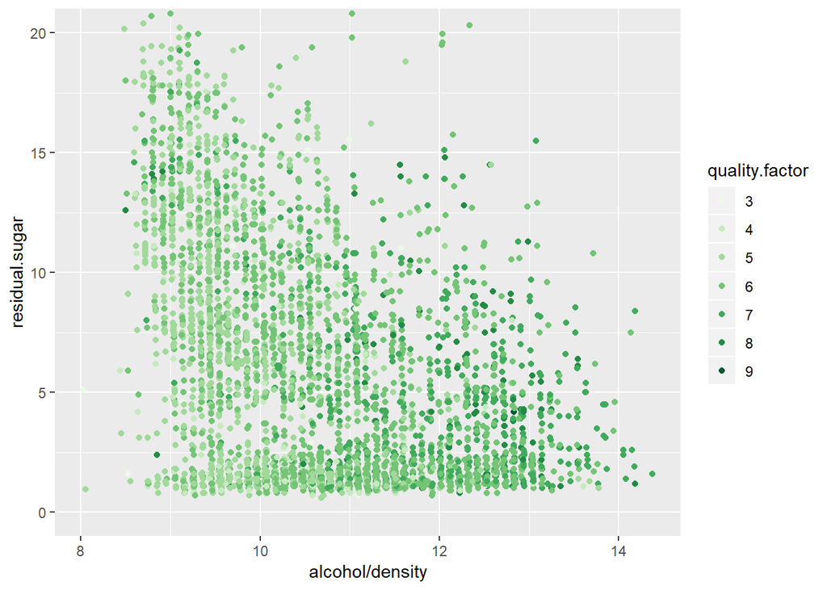

Since there isn’t much of a relationship between citric acid and quality, it seems like the % alcohol is really pulling the darker points to the right on this plot.

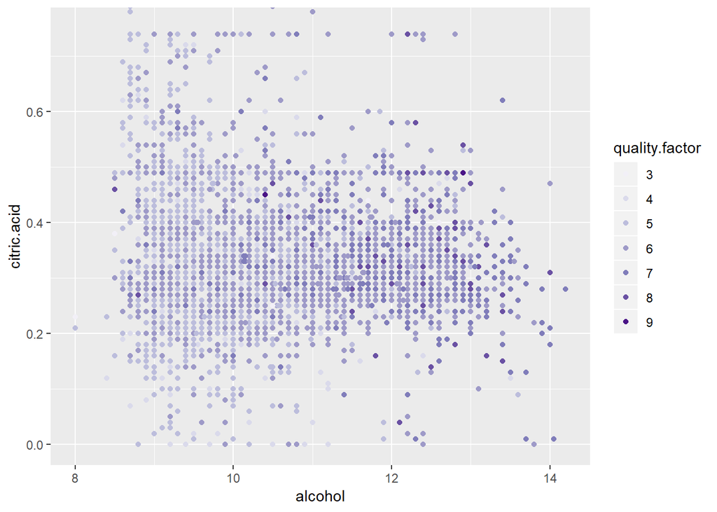

I was also interested in how dryness might play a role. It is difficult to tell since so many of our observations are from dry wines.

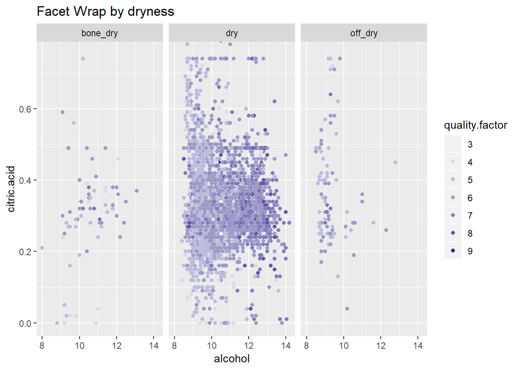

The plot below is somewhat interesting. It seems like The higher quality wines (those rated 7 or above) are really pulled into the bottom right corner. Meaning that a low ratio of citric acid to sugar, and a high alcohol content would lead to a higher quality wine.

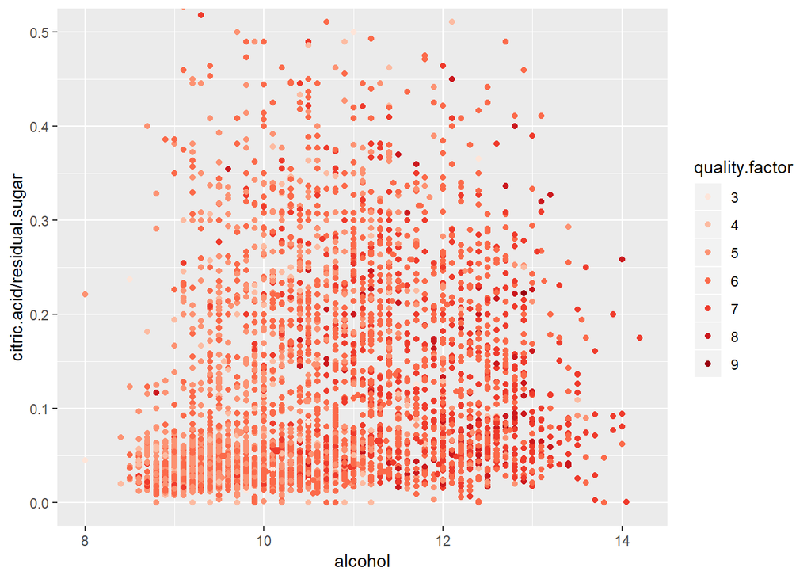

I did a little more research on wine and found that the total sulfur dioxide can affect something called the ‘nose’ of the wine (basically the smell/taste relationship). It seems that the highest concentration of wines with quality scores 7 or above have total sulfur dioxide to alcohol rations between 5 and 20, with a lower residual sugar still giving a higher quality wine.

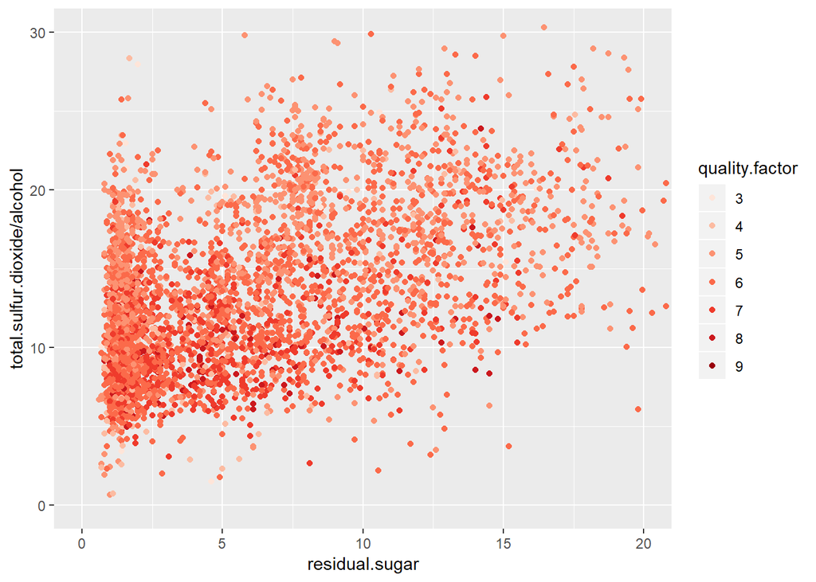

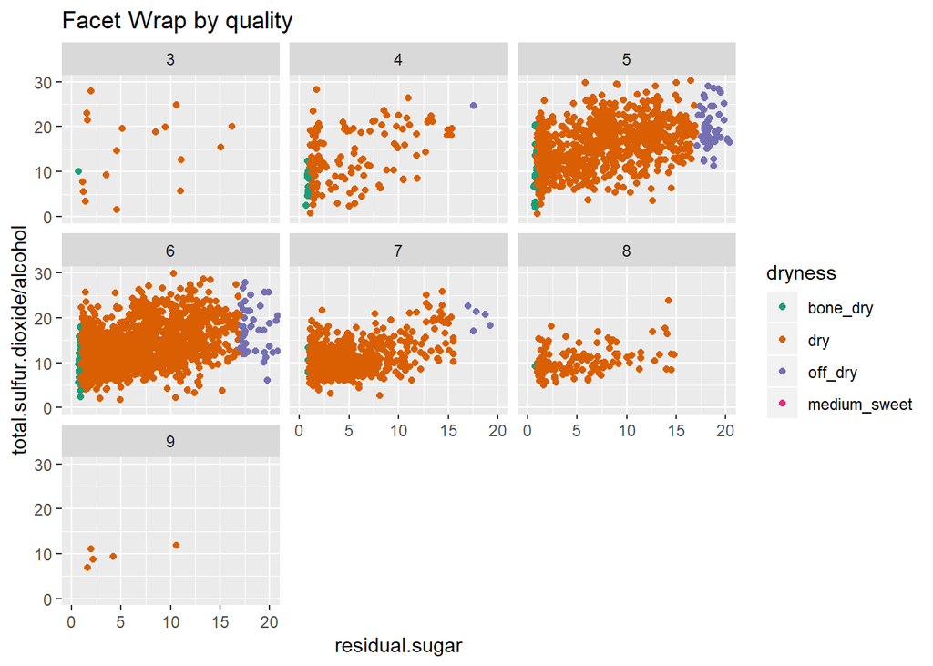

It appears the median residual sugar to alcohol ratio is lowest for quality 9 wines, but the median residual sugar to alcohol ratio for wines of quality 4 is also very low.

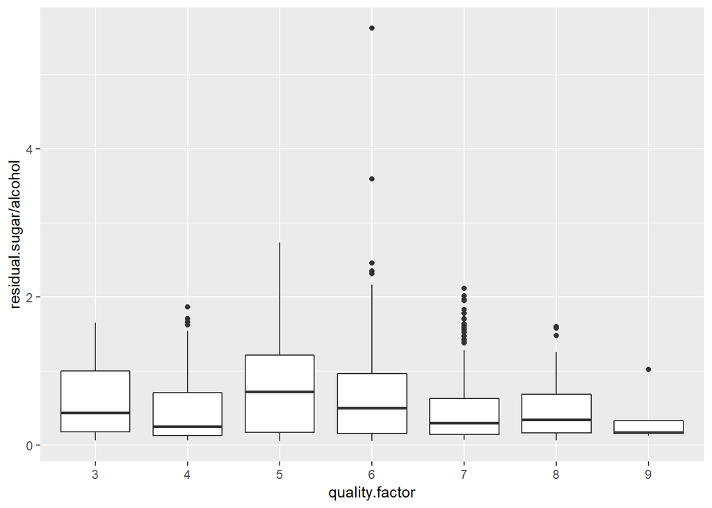

The median citric acid to alcohol ratio is very similar for any quality of wine.

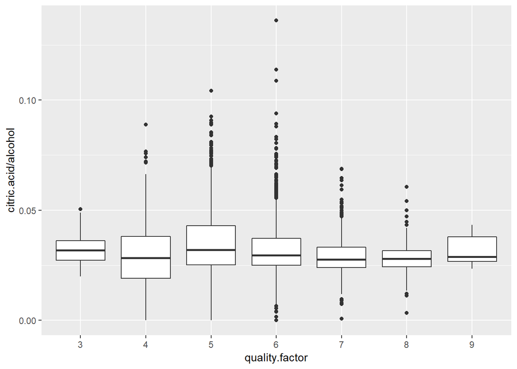

The median citric acid to residual sugar ratio is highest for wines of quality 9.

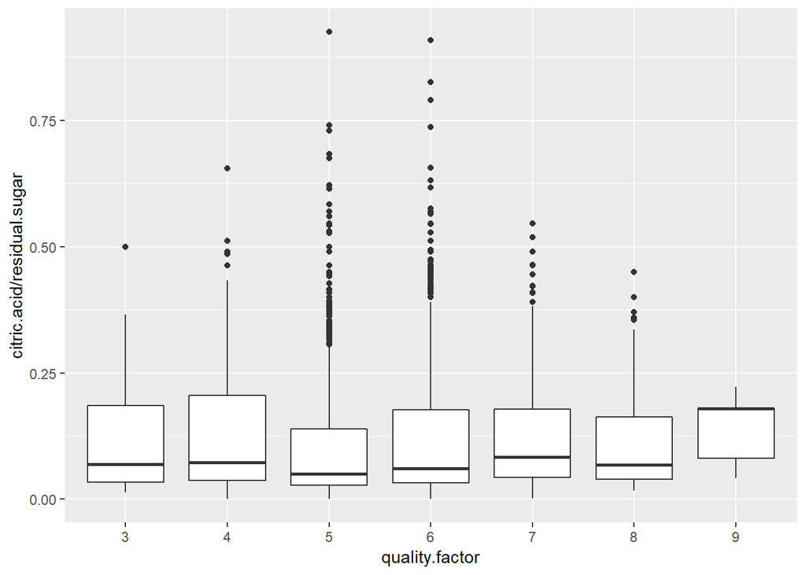

# Multivariate Analysis

It was difficult to distinguish what attributes could accurately predict the quality of the wines. I would suggest that this probably has to do with the subjectivity of the quality score. The attribute that helped me see the best relationship was total sulfur dioxide to alcohol ratio. We could see a somewhat distinct grouping of higher quality wines.

### Were there any interesting or surprising interactions between features?

The most interesting interaction between features came when I plotted alcohol vs. citric acid to residual sugar ratio and colored the points by quality. The highest quality wines were pulled to the right and down, while the lowest quality wines were pulled to the left. This suggests that a higher quality wine wil have a low citric acid to residual sugar ratio along with a higher alcohol content.

# Final Plots and Summary

### Plot One

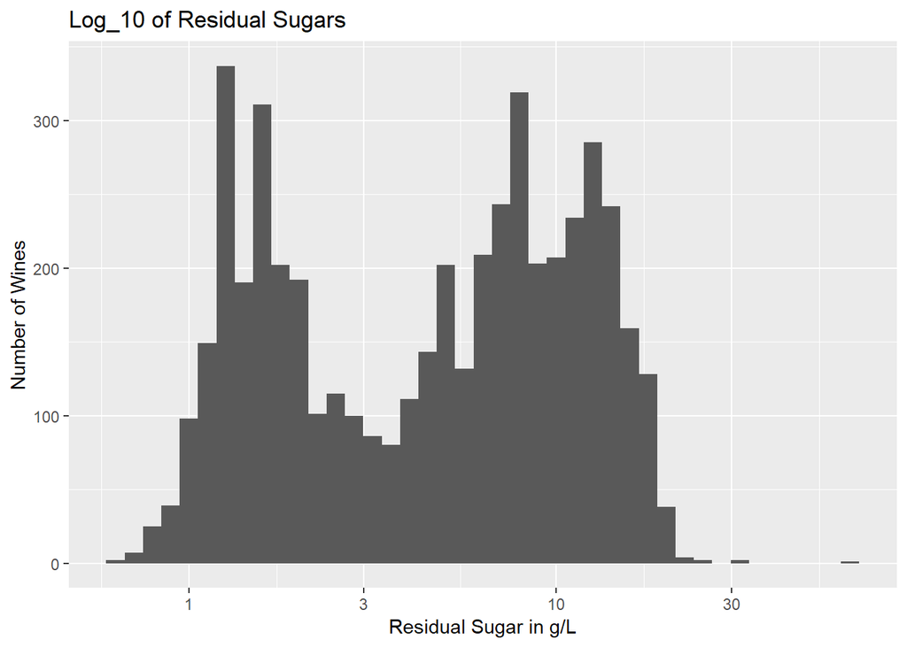

### Description One

The distribution of residual sugars appear to be bimodal on a log scale peaking at approximately 1.5 g/L and 10 g/L.

### Plot Two

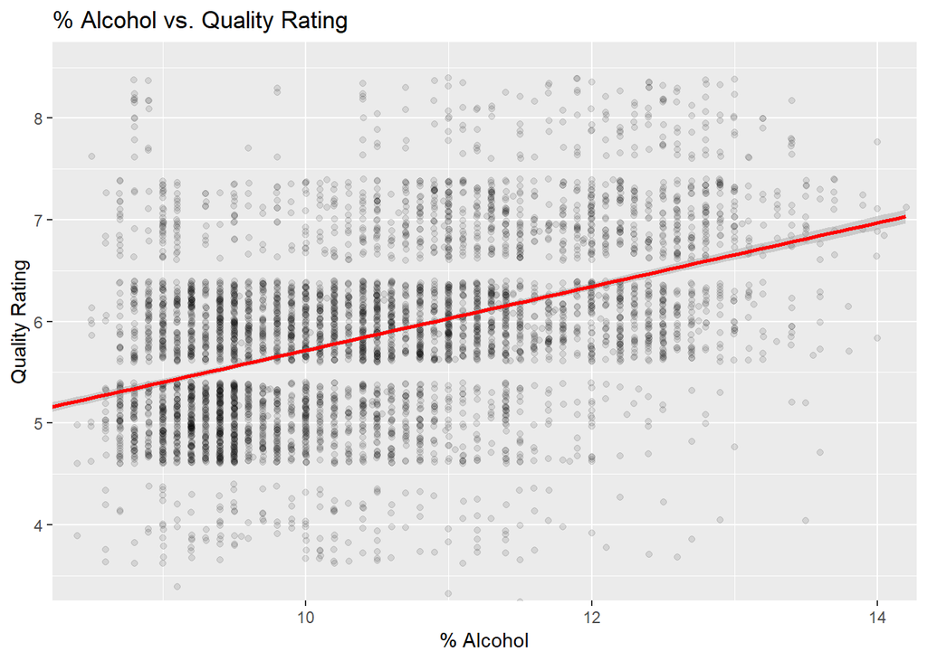

### Description Two

Wines with higher alcohol contents were typically scored higher than wines with lower alcohol contents.

### Plot Three

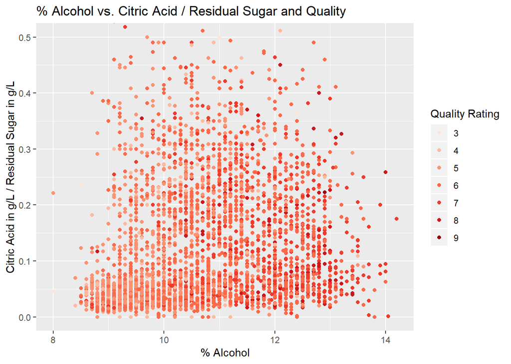

### Description Three

Quality of wine could potentially be predicted by some kind of polynomic model, with alchol and the ratio of citric acid to residual sugar as the input variables.

# Reflection

I don’t have much experience with wines, but it was very interesting to explore these 4,898 observations and the 12 variables that were gathered on them. I explored the quality of the wines across these variables.

This exploration was difficult. I struggled to find meaningful relationships that would appropriately predict the quality of wines. I believe that has to do with the subjectivity of the quality metric. If there was a more objective score, then it might be easier. But coming up with an objective score for something that is so personal would be hard to do.

For future iterations of this work, it would be interesting to build a model that could predict the quality based on some of the relationships that I found. I would also like to do some more research about which wines are best for cooking and see if that could be predicted from the 12 variables we have here.